# Assignment 2

## Task 1

Consider a one-dimensional classification problem with $X = \mathbb{R}$ and $Y = \{−1, +1\}$. The marginal distribution of labels is given as follows:

\begin{align*} p(y=-1)&=\frac{3}{4} & p(y=+1)&=\frac{1}{4} \end{align*}

The conditional distribution $p(x \mid y)$ is given in the following way:

\begin{align*} p(x \mid y=-1) &= \frac{1}{2\sqrt{\pi}}\exp\left(-\frac{(x+1)^2}{4}\right) &&\text{that is }\mathcal{N}\left(\mu_-=-1,\sigma_-^2=2\right) \\ p(x \mid y=+1) &= \frac{\sqrt{2}}{\sqrt{\pi}}\exp\left(-2(x-3)^2\right) &&\text{that is }\mathcal{N}\left(\mu_+=3,\sigma_+^2=\frac{1}{4}\right) \end{align*}

,

where subscripts $-/+$ indicate class memberships. Visualize the marginal distribution $p(x)$ in one plot and the two conditional distributions $p(y = −1 \mid x)$ and $p(y = +1 \mid x)$ together in another plot. Guess from the visualization what the Bayes-optimal classifier is like.

## Task1 — Solution

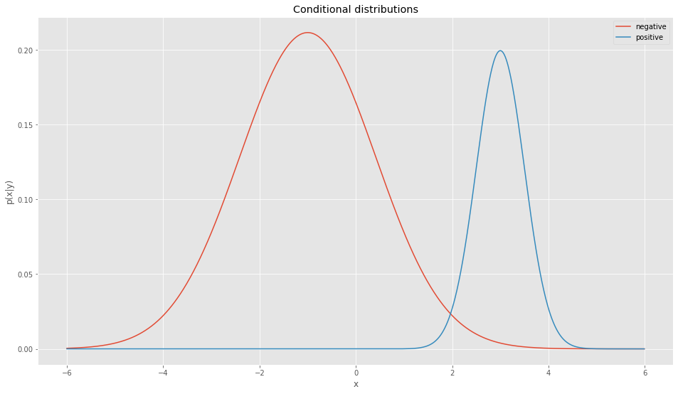

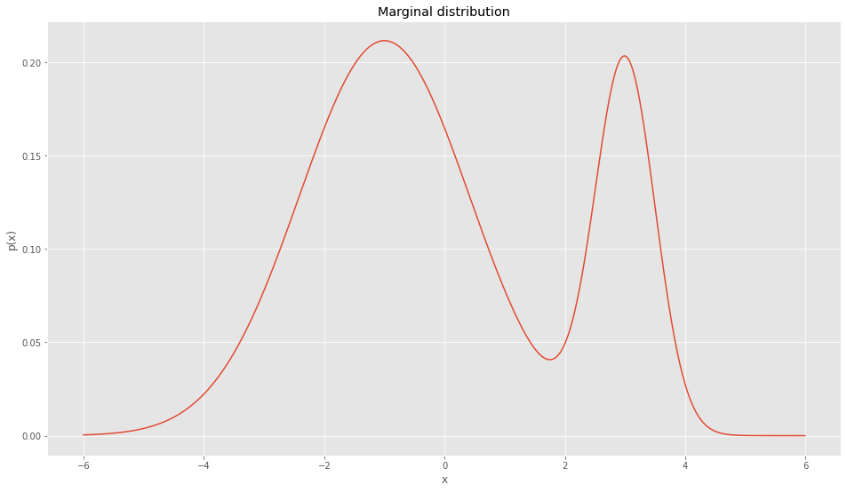

```python
from typing import Union

from matplotlib import pyplot as plt
plt.style.use('ggplot')
import numpy as np
from numpy import pi as PI


def negative(x: Union[float, np.ndarray]) -> Union[float, np.ndarray]:
    return 1/(2*np.sqrt(PI)) * np.exp(((x+1)**2) / -4)

def positive(x: Union[float, np.ndarray]) -> Union[float, np.ndarray]:
    return np.sqrt(2 / PI) * np.exp(-2*(x-3)**2)


x = np.arange(-6, 6, 0.01)

plt.figure(figsize=(16, 9))
plt.title('Conditional distributions')
plt.xlabel('x')
plt.ylabel('p(x|y)')
line_neg, = plt.plot(x, negative(x) * 3/4)
line_pos, = plt.plot(x, positive(x) * 1/4)
plt.legend((line_neg, line_pos), ('negative', 'positive'))
plt.show()

plt.figure(figsize=(16, 9))
plt.title('Marginal distribution')
plt.xlabel('x')
plt.ylabel('p(x)')
plt.plot(x, negative(x) * 3/4 + positive(x) * 1/4)
plt.show()
```

From the visualization I guess that the Bayes-optimal classifier is slightly below $2$.

## Task 2

Compute the Bayes-optimal decision boundary from Task 1 by choosing an appropriate discriminant function $g(x)$ and letting $g(x) = 0$ (hint: double-click the markdown cells of this notebook to see how you can TeX the math)

\begin{equation} g(x) = \frac{1}{2\sqrt{\pi}}\exp\left(-\frac{(x+1)^2}{4}\right)\frac{3}{4} - \frac{\sqrt{2}}{\sqrt{\pi}} \exp\left(-2(x-3)^2\right)\frac{1}{4} = 0 \end{equation}\begin{equation} \frac{3}{8\sqrt{\pi}}\exp\left(-\frac{(x+1)^2}{4}\right) = \frac{\sqrt{2}}{4\sqrt{\pi}}\exp\left(-2(x-3)^2\right) \> \big| \cdot \sqrt{\pi} \end{equation}\begin{equation} \frac{3}{8}\exp\left(-\frac{(x+1)^2}{4}\right) = \frac{\sqrt{2}}{4}\exp\left(-2(x-3)^2\right) \> \big| \cdot 4 \end{equation}\begin{equation} \frac{3}{2}\exp\left(-\frac{(x+1)^2}{4}\right) = \sqrt{2}\exp\left(-2(x-3)^2\right) \> \big| \> / \sqrt{2} \end{equation}

\begin{equation} \frac{3}{2\sqrt{2}}\exp\left(-\frac{(x+1)^2}{4}\right) = \exp\left(-2(x-3)^2\right) \> \big| \> / \exp\left(-\frac{(x+1)^2}{4}\right) \end{equation}\begin{equation} \frac{3}{2\sqrt{2}} = \frac{\exp\left(-2(x-3)^2\right)}{\exp\left(-\frac{(x+1)^2}{4}\right)} \> \big| \> \text{rewrite} \end{equation}\begin{equation} \frac{3}{2\sqrt{2}} = e^{\left(-2(x-3)^2\right) - \left(-\frac{(x+1)^2}{4}\right)} \> \big| \> \text{simplify} \end{equation}\begin{equation} \frac{3}{2\sqrt{2}} = e^{-2(x-3)^2 + \frac{(x+1)^2}{4}} \> \big| \> ln(.) \end{equation}

\begin{equation} ln\left(\frac{3}{2\sqrt{2}}\right) = -2(x-3)^2 + \frac{(x+1)^2}{4} \end{equation}\begin{equation} ln\left(\frac{3}{2\sqrt{2}}\right) = -2(x^2 - 6x + 9) + \frac{x^2 + 2x + 1}{4} \end{equation}\begin{equation} ln\left(\frac{3}{2\sqrt{2}}\right) = -2x^2 + 12x - 18 + \frac{x^2 + 2x + 1}{4} \end{equation}\begin{equation} ln\left(\frac{3}{2\sqrt{2}}\right) = -\frac{7x^2}{4} + \frac{50x}{4} - \frac{71}{4} \> \big| \> - ln\left(\frac{3}{2\sqrt{2}}\right) \end{equation}

\begin{equation} -\frac{7x^2}{4} + \frac{50x}{4} - \frac{71}{4} - ln\left(\frac{3}{2\sqrt{2}}\right) = 0 \> \big| \> \cdot \frac{-4}{7} \end{equation}\begin{equation} x^2 - \frac{50x}{7} + \frac{71}{7} + \frac{4}{7} ln\left(\frac{3}{2\sqrt{2}}\right) = 0 \end{equation}

\begin{equation} x_1 = \frac{50}{14} - \sqrt{\left(\frac{50}{14}\right)^2 - \frac{71}{7} - \frac{4}{7} ln\left(\frac{3}{2\sqrt{2}}\right)} = 1.965... \\ x_2 = \frac{50}{14} + \sqrt{\left(\frac{50}{14}\right)^2 - \frac{71}{7} - \frac{4}{7} ln\left(\frac{3}{2\sqrt{2}}\right)} = 5.177... \end{equation}

Thus we can see that the Bayes-optimal classifier is $\approx$ 1.966

## Task 2 — Solution

```python
x = (50/14) + np.asarray([-1, 1])*np.sqrt((50/14)**2 - (71/7) - (4/7)*np.log(3/(2*np.sqrt(2))))

print(f'x1 = {x[0]:.4f}', f'x2 = {x[1]:.4f}', sep='\n')
```

```
x1 = 1.9656
x2 = 5.1772
```

## Task 3

Consider the following one-dimensional regression task: inputs $x$ are uniformly distributed in $[−1, 3] \subset \mathbb{R}$ and targets $y$ are given as

\begin{gather*} f(x) = 0.6x^4 + 2x^3 - 8x^2 \\ y = f(x) + \varepsilon, \end{gather*}

where $\varepsilon$ is independent normally distributied noise with $\mu=0$ and $\sigma^2 = 0.09$. What are $\operatorname{E}(y \mid x_0)$ and the unavoidable error $\operatorname{Var}(y \mid x_0)$ for a fixed $x_0$ in this setting?

## Task 3 — Solution

According to slideset 2 page 11:

\begin{equation} \operatorname{E}(y \mid x_0) = \\ f(x_0) + \varepsilon = \\ 0.6x_0^4 + 2x_0^3 - 8x_0^2 + \varepsilon = \\ 0.6x_0^4 + 2x_0^3 - 8x_0^2 + \mathcal{N}\left(\mu=0,\sigma^2=0.09\right) \end{equation}

Since $\operatorname{E}(\mathcal{N}\left(\mu=0,\sigma^2=0.09\right)) = 0 \xrightarrow{} \operatorname{E}(y \mid x_0) = f(x_0)$

The unavoidable error $\operatorname{Var}(y \mid x_0)$ might be measuring or calculation limitations.

## Task 4

Perform polynomial regression to illustrate the bias-variance decomposition of Task 3. To this end, perform the following steps for each degree $n = 1, \dots, 12$:

1. Create 200 training sets with $l=20$ samples each.
2. For each of the training sets, train a polynomial model with degree $n$ and compute the predicted value for $x_0 = 1.8$.
3. Estimate the squared bias and the variance from the 200 predicted values and compute an overall estimate for the expected prediction error for $x_0 = 1.8$.

After having followed these steps, visualize your results appropriately. Discuss how the results illustrate the bias-variance decomposition.

## Task 4 — Solution

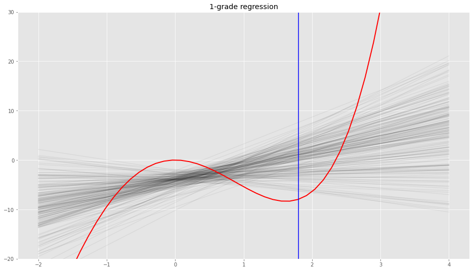

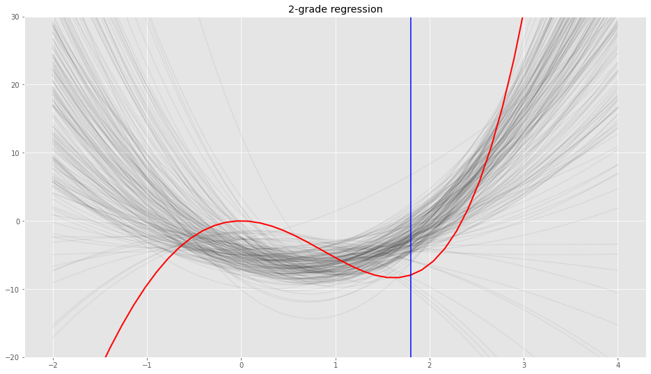

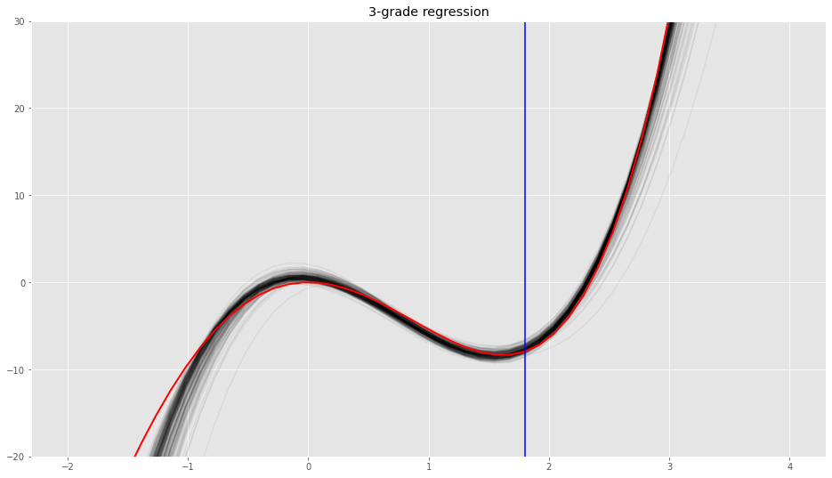

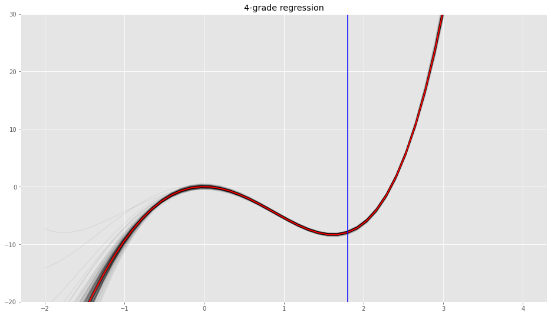

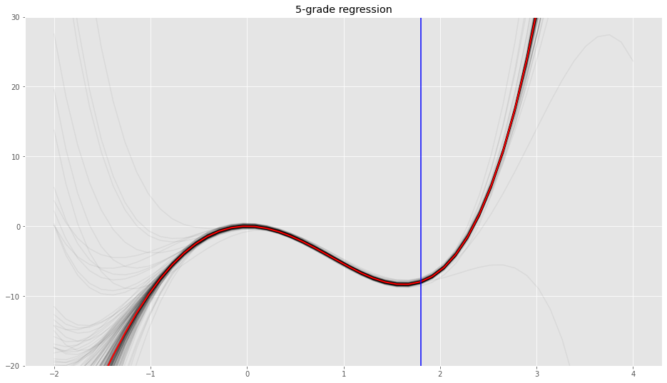

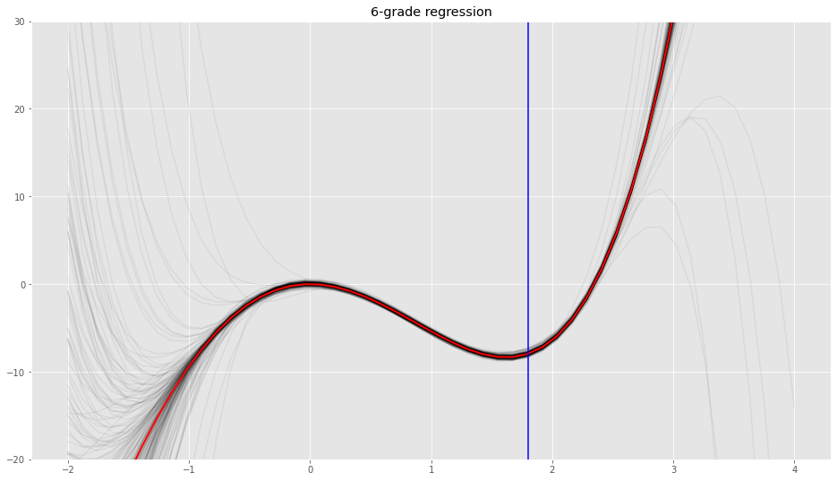

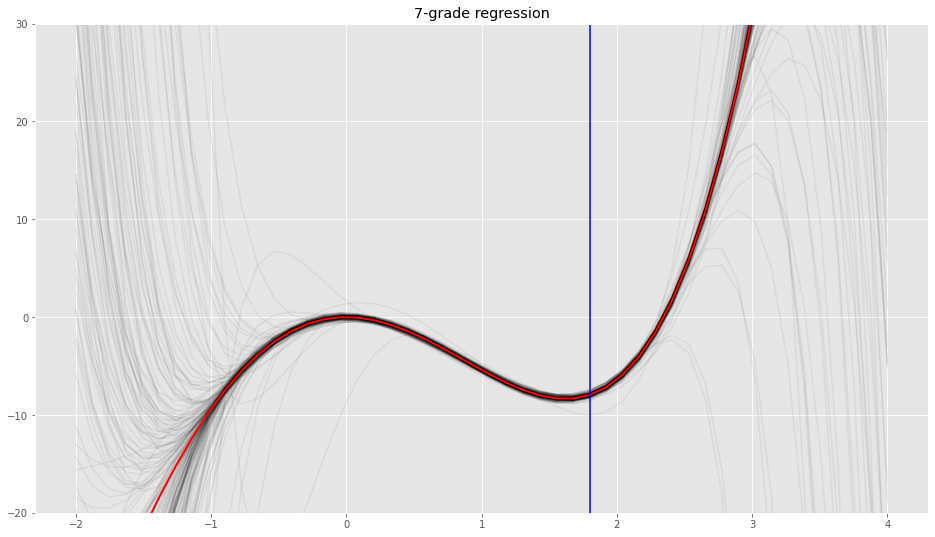

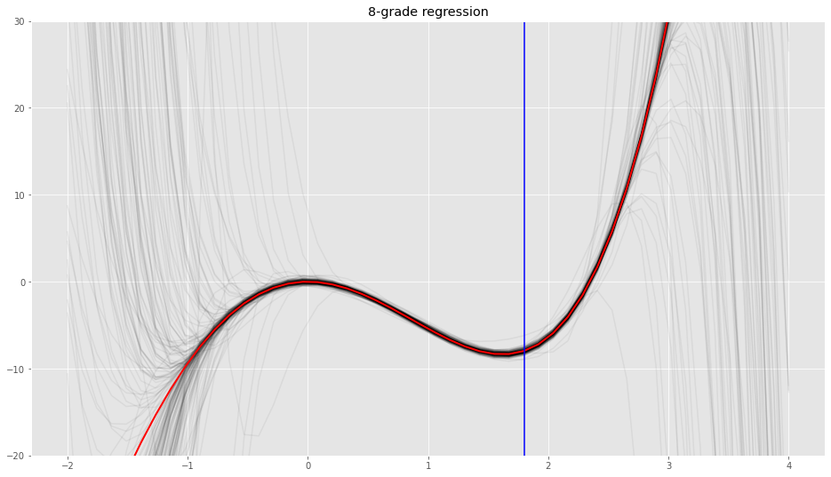

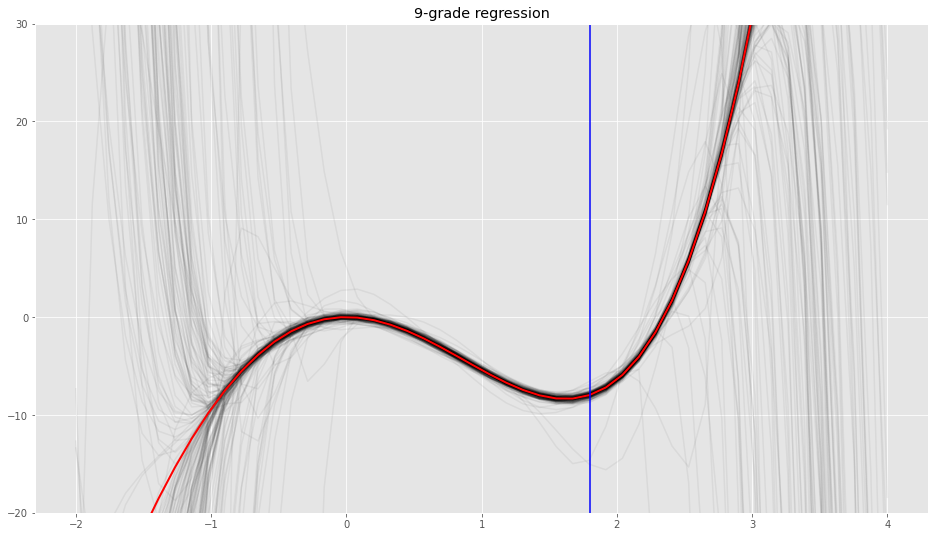

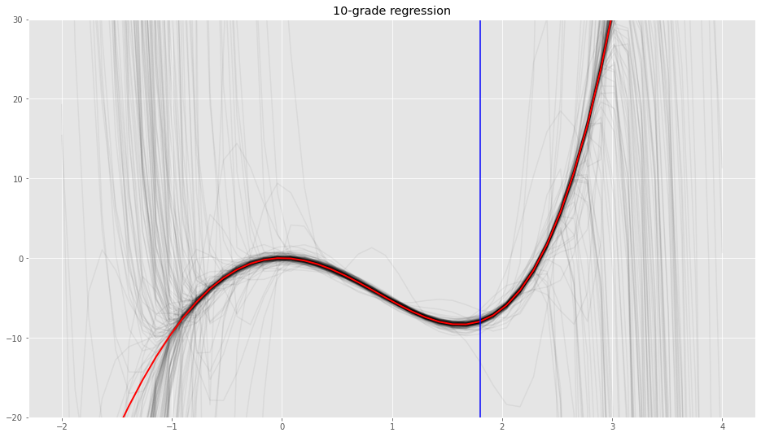

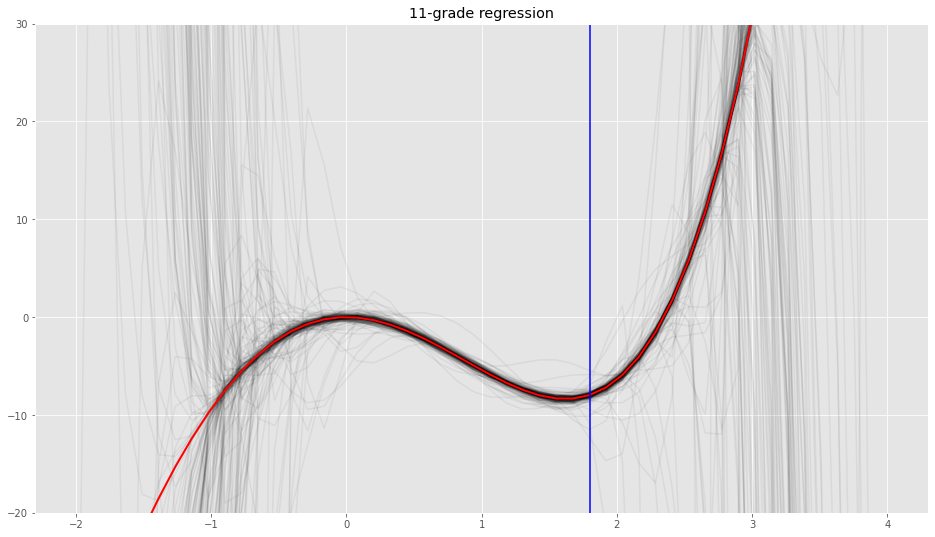

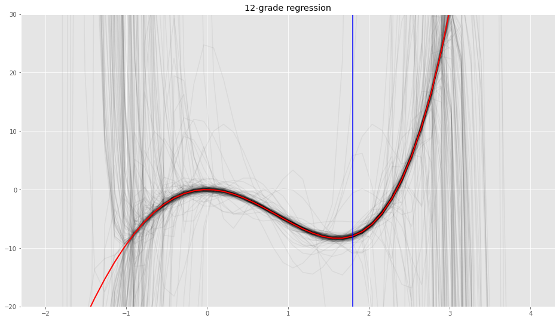

```
[n= 1] MSE:  76.7901  MEAN:   0.3410  VAR:   7.9267
[n= 2] MSE:  35.4250  MEAN:  -2.3963  VAR:   4.4987
[n= 3] MSE:   0.2343  MEAN:  -7.6617  VAR:   0.1468
[n= 4] MSE:   0.0174  MEAN:  -7.9532  VAR:   0.0173
[n= 5] MSE:   0.0286  MEAN:  -7.9726  VAR:   0.0283
[n= 6] MSE:   0.0432  MEAN:  -7.9393  VAR:   0.0429
[n= 7] MSE:   0.0582  MEAN:  -7.9647  VAR:   0.0582
[n= 8] MSE:   0.0797  MEAN:  -7.9749  VAR:   0.0793
[n= 9] MSE:   0.5562  MEAN:  -8.0165  VAR:   0.5528
[n=10] MSE:   0.2650  MEAN:  -7.9876  VAR:   0.2641
[n=11] MSE:   0.4146  MEAN:  -8.0189  VAR:   0.4109
[n=12] MSE:  77.9726  MEAN:  -7.3843  VAR:  77.6442
```

[1 more figures not shown]

```python
def f(x: Union[float, np.ndarray]) -> Union[float, np.ndarray]:
    return 0.6*x**4 + 2*x**3 - 8*x**2


def f_noise(x: np.ndarray) -> np.ndarray:
    return f(x) + np.random.normal(0, np.sqrt(0.09), len(x))


# for reproducibility
np.random.seed(17)

lower, upper = -1, 3
n_samples = 200
l = 20
n = list(range(1, 13))
x0 = 1.8

predictions = np.zeros((len(n), n_samples))
x_vals = np.linspace(lower - 1, upper + 1, 50)

for k in n:
    plt.figure(figsize=(16, 9))
    for i in range(n_samples):
        x = np.random.sample(l) * (upper - lower) + lower
        y = f_noise(x)

        poly = np.polyfit(x, y, k)
        regress_function = np.poly1d(poly)
        predictions[k - 1, i] = regress_function(x0)

        plt.plot(x_vals, regress_function(x_vals), color='k', alpha=0.05)

    plt.title(f'{k}-grade regression')
    plt.ylim((-20, 30))
    plt.plot(x_vals, f(x_vals), color='r', linewidth=2)
    plt.axvline(x=x0, color='b')
    plt.show()


for i, line in enumerate(predictions):
    print(f'[n={i+1:2d}] MSE: {np.mean((line - f(x0))**2):8.4f}  MEAN: {line.mean():8.4f}  VAR: {line.var():8.4f}')

plt.figure(figsize=(16, 9))
plt.title('Bias squared')
plt.plot(
    n,
    [np.mean((predictions[i - 1, :] - f(x0))**2) for i in n],
    color='r',
    linestyle='dashed',
    marker='o',
    markerfacecolor='b'
)
plt.xlabel('n')
plt.show()
```

### Discussion

We can see that very low $n$s leads to underfitting - the original polynomial function is of grade 4 (but looks like grade 3), so we need $n \ge 3$ in order to approximate the function well.

Very large $n$s lead to overfitting - the samples of the original polynomial function are overfitted grossly, as we can see in '12-grade regression'. One outlier alone skews the results immensely.